# 数据集属性字段分析

## 数值属性（25项）

DBNOs - 击倒敌人的数量

assists - 造成伤害但被队友击杀的敌方玩家的数目（助攻数）

boosts - 使用能量道具的数量

damageDealt - 对敌人造成的总伤害

headshotKills - 爆头击杀数量

heals - 使用治疗道具的数量

killPlace - 本场比赛的杀敌数排名

killPoints - 基于击杀数的外部Elo Rating

killStreaks - 连续击杀数（在短时间内）

kills - 杀敌数

longestKill - 最远杀敌距离（由于计算的是敌方玩家死亡而不是被击倒时与玩家的距离，因为在敌方玩家被击倒后玩家乘坐载具离开会导致最远杀敌距离变长，因此并不是特别准确）

matchDuration - 比赛时长

rankPoints - Elo排名，官方建议谨慎使用。

revives - 复活队友的次数

rideDistance - 使用载具移动的距离

roadKills - 使用载具击杀敌方玩家的数量

swimDistance - 游泳距离

teamKills - 杀死队友的数量

vehicleDestroys - 破坏载具的数量

walkDistance - 步行距离

weaponsAcquired - 捡起武器的数量

winPoints - 基于胜场的外部Elo Rating

numGroups - 该场比赛的小队数量

maxPlace - 本局的最差名次，可能与小队数量不同，因为会有名次并列。

winPlacePerc - 百分比排名（预测属性）1代表玩家排名第一，0代表玩家排名为倒数第一。百分比是按照本局的最差名次来计算的，而不是小队的数量。

## 标称属性（4项）

Id - 玩家ID

matchId - 比赛ID，训练集合测试集的比赛ID不会重合

matchType - 比赛（组队）类型，String类型，包括第一人称和第三人称的单排、双排、四排，其余模式来自自定义匹配。

groupId - 小队ID，同一组玩家组成的小队在不同比赛里的小队ID也不同

```python
%matplotlib inline
import warnings
warnings.filterwarnings('ignore')

import os
import copy
import math
import scipy

import numpy as np
import pandas as pd
import matplotlib.pyplot as plt
import seaborn as sns
```

```python
train = pd.read_csv("../input/pubg-finish-placement-prediction/train_V2.csv")
```

观察训练集的基本信息

```python
train.info()
```

```
<class 'pandas.core.frame.DataFrame'>
RangeIndex: 4446966 entries, 0 to 4446965
Data columns (total 29 columns):
Id                 object
groupId            object
matchId            object
assists            int64
boosts             int64
damageDealt        float64
DBNOs              int64
headshotKills      int64
heals              int64
killPlace          int64
killPoints         int64
kills              int64
killStreaks        int64
longestKill        float64
matchDuration      int64
matchType          object
maxPlace           int64
numGroups          int64
rankPoints         int64
revives            int64
rideDistance       float64
roadKills          int64
swimDistance       float64
teamKills          int64
vehicleDestroys    int64
walkDistance       float64
weaponsAcquired    int64
winPoints          int64
winPlacePerc       float64
dtypes: float64(6), int64(19), object(4)
memory usage: 983.9+ MB
```

```python
nominal_columns = ['Id','groupId', 'matchId', 'matchType']
```

```python
train.head(5)
```

|  | Id | groupId | matchId | assists | boosts | damageDealt | DBNOs | headshotKills | heals | killPlace | ... | revives | rideDistance | roadKills | swimDistance | teamKills | vehicleDestroys | walkDistance | weaponsAcquired | winPoints | winPlacePerc |
| --- | --- | --- | --- | --- | --- | --- | --- | --- | --- | --- | --- | --- | --- | --- | --- | --- | --- | --- | --- | --- | --- |
| 0 | 7f96b2f878858a | 4d4b580de459be | a10357fd1a4a91 | 0 | 0 | 0.00 | 0 | 0 | 0 | 60 | ... | 0 | 0.0000 | 0 | 0.00 | 0 | 0 | 244.80 | 1 | 1466 | 0.4444 |
| 1 | eef90569b9d03c | 684d5656442f9e | aeb375fc57110c | 0 | 0 | 91.47 | 0 | 0 | 0 | 57 | ... | 0 | 0.0045 | 0 | 11.04 | 0 | 0 | 1434.00 | 5 | 0 | 0.6400 |
| 2 | 1eaf90ac73de72 | 6a4a42c3245a74 | 110163d8bb94ae | 1 | 0 | 68.00 | 0 | 0 | 0 | 47 | ... | 0 | 0.0000 | 0 | 0.00 | 0 | 0 | 161.80 | 2 | 0 | 0.7755 |
| 3 | 4616d365dd2853 | a930a9c79cd721 | f1f1f4ef412d7e | 0 | 0 | 32.90 | 0 | 0 | 0 | 75 | ... | 0 | 0.0000 | 0 | 0.00 | 0 | 0 | 202.70 | 3 | 0 | 0.1667 |
| 4 | 315c96c26c9aac | de04010b3458dd | 6dc8ff871e21e6 | 0 | 0 | 100.00 | 0 | 0 | 0 | 45 | ... | 0 | 0.0000 | 0 | 0.00 | 0 | 0 | 49.75 | 2 | 0 | 0.1875 |

5 rows × 29 columns

# 数据预处理

## 异常值处理

### 删除缺失值

```python
train.isnull().sum()
```

```
Id                 0
groupId            0
matchId            0
assists            0
boosts             0
damageDealt        0
DBNOs              0
headshotKills      0
heals              0
killPlace          0
killPoints         0
kills              0
killStreaks        0
longestKill        0
matchDuration      0
matchType          0
maxPlace           0
numGroups          0
rankPoints         0
revives            0
rideDistance       0
roadKills          0
swimDistance       0
teamKills          0
vehicleDestroys    0
walkDistance       0
weaponsAcquired    0
winPoints          0
winPlacePerc       1
dtype: int64
```

```python
idx = train['winPlacePerc'].isnull()
train[idx].head()
```

|  | Id | groupId | matchId | assists | boosts | damageDealt | DBNOs | headshotKills | heals | killPlace | ... | revives | rideDistance | roadKills | swimDistance | teamKills | vehicleDestroys | walkDistance | weaponsAcquired | winPoints | winPlacePerc |
| --- | --- | --- | --- | --- | --- | --- | --- | --- | --- | --- | --- | --- | --- | --- | --- | --- | --- | --- | --- | --- | --- |
| 2744604 | f70c74418bb064 | 12dfbede33f92b | 224a123c53e008 | 0 | 0 | 0.0 | 0 | 0 | 0 | 1 | ... | 0 | 0.0 | 0 | 0.0 | 0 | 0 | 0.0 | 0 | 0 | NaN |

1 rows × 29 columns

```python
train = train.dropna(axis=0,how='any')
```

```python
train.head(5)
```

|  | Id | groupId | matchId | assists | boosts | damageDealt | DBNOs | headshotKills | heals | killPlace | ... | revives | rideDistance | roadKills | swimDistance | teamKills | vehicleDestroys | walkDistance | weaponsAcquired | winPoints | winPlacePerc |
| --- | --- | --- | --- | --- | --- | --- | --- | --- | --- | --- | --- | --- | --- | --- | --- | --- | --- | --- | --- | --- | --- |
| 0 | 7f96b2f878858a | 4d4b580de459be | a10357fd1a4a91 | 0 | 0 | 0.00 | 0 | 0 | 0 | 60 | ... | 0 | 0.0000 | 0 | 0.00 | 0 | 0 | 244.80 | 1 | 1466 | 0.4444 |
| 1 | eef90569b9d03c | 684d5656442f9e | aeb375fc57110c | 0 | 0 | 91.47 | 0 | 0 | 0 | 57 | ... | 0 | 0.0045 | 0 | 11.04 | 0 | 0 | 1434.00 | 5 | 0 | 0.6400 |
| 2 | 1eaf90ac73de72 | 6a4a42c3245a74 | 110163d8bb94ae | 1 | 0 | 68.00 | 0 | 0 | 0 | 47 | ... | 0 | 0.0000 | 0 | 0.00 | 0 | 0 | 161.80 | 2 | 0 | 0.7755 |
| 3 | 4616d365dd2853 | a930a9c79cd721 | f1f1f4ef412d7e | 0 | 0 | 32.90 | 0 | 0 | 0 | 75 | ... | 0 | 0.0000 | 0 | 0.00 | 0 | 0 | 202.70 | 3 | 0 | 0.1667 |
| 4 | 315c96c26c9aac | de04010b3458dd | 6dc8ff871e21e6 | 0 | 0 | 100.00 | 0 | 0 | 0 | 45 | ... | 0 | 0.0000 | 0 | 0.00 | 0 | 0 | 49.75 | 2 | 0 | 0.1875 |

5 rows × 29 columns

### 删除有击杀但没有移动过的数据

有击杀但没有任何移动很大概率是异常的数据

```python
train['totalDistance'] = train['rideDistance'] + train['walkDistance'] + train['swimDistance']
train['killsWithoutMoving'] = ((train['kills'] > 0) & (train['totalDistance'] == 0))
train["killsWithoutMoving"].head()
```

```
0    False
1    False
2    False
3    False
4    False
Name: killsWithoutMoving, dtype: bool
```

```python
display(train[train['killsWithoutMoving'] == True].head())
train.drop(train[train['killsWithoutMoving'] == True].index, inplace=True)
```

|  | Id | groupId | matchId | assists | boosts | damageDealt | DBNOs | headshotKills | heals | killPlace | ... | roadKills | swimDistance | teamKills | vehicleDestroys | walkDistance | weaponsAcquired | winPoints | winPlacePerc | totalDistance | killsWithoutMoving |
| --- | --- | --- | --- | --- | --- | --- | --- | --- | --- | --- | --- | --- | --- | --- | --- | --- | --- | --- | --- | --- | --- |
| 1824 | b538d514ef2476 | 0eb2ce2f43f9d6 | 35e7d750e442e2 | 0 | 0 | 593.0 | 0 | 0 | 3 | 18 | ... | 0 | 0.0 | 0 | 0 | 0.0 | 8 | 0 | 0.8571 | 0.0 | True |
| 6673 | 6d3a61da07b7cb | 2d8119b1544f87 | 904cecf36217df | 2 | 0 | 346.6 | 0 | 0 | 6 | 33 | ... | 0 | 0.0 | 0 | 0 | 0.0 | 22 | 0 | 0.6000 | 0.0 | True |
| 11892 | 550398a8f33db7 | c3fd0e2abab0af | db6f6d1f0d4904 | 2 | 0 | 1750.0 | 0 | 4 | 5 | 3 | ... | 0 | 0.0 | 0 | 0 | 0.0 | 13 | 0 | 0.8947 | 0.0 | True |
| 14631 | 58d690ee461e9d | ea5b6630b33d67 | dbf34301df5e53 | 0 | 0 | 157.8 | 0 | 0 | 0 | 69 | ... | 0 | 0.0 | 0 | 0 | 0.0 | 7 | 1500 | 0.0000 | 0.0 | True |
| 15591 | 49b61fc963d632 | 0f5c5f19d9cc21 | 904cecf36217df | 0 | 0 | 100.0 | 0 | 1 | 0 | 37 | ... | 0 | 0.0 | 0 | 0 | 0.0 | 10 | 0 | 0.3000 | 0.0 | True |

5 rows × 31 columns

### 删除爆头率异常数据

```python
train['headshot_rate'] = train['headshotKills'] / train['kills']
train['headshot_rate'] = train['headshot_rate'].fillna(0)
train["headshot_rate"].head()
```

```
0    0.0
1    0.0
2    0.0
3    0.0
4    0.0
Name: headshot_rate, dtype: float64
```

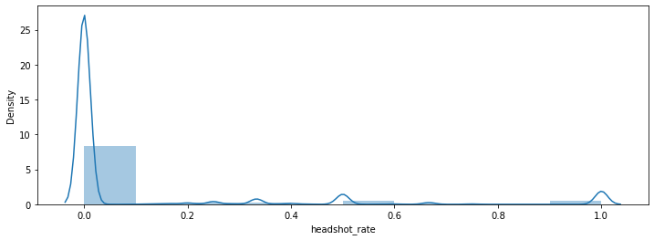

```python
plt.figure(figsize=(12,4))
sns.distplot(train['headshot_rate'], bins=10)
plt.show()
```

通过可视化爆头率数据我们可以发现，有部分数据的爆头率是接近100%，我们决定删除击杀数大于9但爆头率为100%的玩家数据

```python
print(train[(train['headshot_rate'] == 1) & (train['kills'] > 9)].shape)
train[(train['headshot_rate'] == 1) & (train['kills'] > 9)].head()
```

```
(24, 32)
```

|  | Id | groupId | matchId | assists | boosts | damageDealt | DBNOs | headshotKills | heals | killPlace | ... | swimDistance | teamKills | vehicleDestroys | walkDistance | weaponsAcquired | winPoints | winPlacePerc | totalDistance | killsWithoutMoving | headshot_rate |
| --- | --- | --- | --- | --- | --- | --- | --- | --- | --- | --- | --- | --- | --- | --- | --- | --- | --- | --- | --- | --- | --- |
| 281570 | ab9d7168570927 | add05ebde0214c | e016a873339c7b | 2 | 3 | 1212.0 | 8 | 10 | 0 | 1 | ... | 0.0 | 0 | 0 | 2939.0 | 5 | 0 | 0.8462 | 2939.0 | False | 1.0 |
| 346124 | 044d18fc42fc75 | fc1dbc2df6a887 | 628107d4c41084 | 3 | 5 | 1620.0 | 13 | 11 | 3 | 1 | ... | 0.0 | 0 | 0 | 3422.0 | 8 | 1560 | 1.0000 | 8142.0 | False | 1.0 |
| 871244 | e668a25f5488e3 | 5ba8feabfb2a23 | f6e6581e03ba4f | 0 | 4 | 1365.0 | 9 | 13 | 0 | 1 | ... | 0.0 | 0 | 0 | 2105.0 | 5 | 1587 | 1.0000 | 2105.0 | False | 1.0 |
| 908815 | 566d8218b705aa | a9b056478d71b2 | 3a41552d553583 | 2 | 5 | 1535.0 | 10 | 10 | 3 | 1 | ... | 0.0 | 2 | 0 | 2761.0 | 7 | 1519 | 0.9630 | 7948.0 | False | 1.0 |
| 963463 | 1bd6fd288df4f0 | 90584ffa22fe15 | ba2de992ec7bb8 | 2 | 6 | 1355.0 | 12 | 10 | 2 | 1 | ... | 0.0 | 0 | 0 | 2458.0 | 4 | 1562 | 1.0000 | 3476.0 | False | 1.0 |

5 rows × 32 columns

```python
train.drop(train[(train['headshot_rate'] == 1) & (train['kills'] > 9)].index, inplace=True)
```

## 标称属性处理

### 比赛类型one-hot处理

在这里我们对比赛类型进行了one-hot数值化处理，方便构建与比赛类型有关的特征。

```python
train['matchType'].unique()
```

```
array(['squad-fpp', 'duo', 'solo-fpp', 'squad', 'duo-fpp', 'solo',
       'normal-squad-fpp', 'crashfpp', 'flaretpp', 'normal-solo-fpp',
       'flarefpp', 'normal-duo-fpp', 'normal-duo', 'normal-squad',
       'crashtpp', 'normal-solo'], dtype=object)
```

```python
train = train.join(pd.get_dummies(train.matchType))
train.shape
```

```
(4445406, 48)
```

```python
# 通过正则匹配查看具体内容
matchType_encoding = train.filter(regex='matchType').astype(str)
matchType_encoding.head()
```

|  | matchType |
| --- | --- |
| 0 | squad-fpp |
| 1 | squad-fpp |
| 2 | duo |
| 3 | squad-fpp |
| 4 | solo-fpp |

# 数据分析

## 数值属性分析

### 数值属性五数概括

```python
train.describe()
```

|  | assists | boosts | damageDealt | DBNOs | headshotKills | heals | killPlace | killPoints | kills | killStreaks | ... | normal-duo | normal-duo-fpp | normal-solo | normal-solo-fpp | normal-squad | normal-squad-fpp | solo | solo-fpp | squad | squad-fpp |
| --- | --- | --- | --- | --- | --- | --- | --- | --- | --- | --- | --- | --- | --- | --- | --- | --- | --- | --- | --- | --- | --- |
| count | 4.445406e+06 | 4.445406e+06 | 4.445406e+06 | 4.445406e+06 | 4.445406e+06 | 4.445406e+06 | 4.445406e+06 | 4.445406e+06 | 4.445406e+06 | 4.445406e+06 | ... | 4.445406e+06 | 4.445406e+06 | 4.445406e+06 | 4.445406e+06 | 4.445406e+06 | 4.445406e+06 | 4.445406e+06 | 4.445406e+06 | 4.445406e+06 | 4.445406e+06 |
| mean | 2.333089e-01 | 1.107193e+00 | 1.305575e+02 | 6.576340e-01 | 2.263847e-01 | 1.369974e+00 | 4.760660e+01 | 5.050392e+02 | 9.231791e-01 | 5.435881e-01 | ... | 4.341561e-05 | 1.217212e-03 | 6.321132e-05 | 3.385518e-04 | 1.023529e-04 | 3.650510e-03 | 4.092315e-02 | 1.207111e-01 | 1.409352e-01 | 3.950492e-01 |
| std | 5.868948e-01 | 1.715920e+00 | 1.702703e+02 | 1.144092e+00 | 6.001951e-01 | 2.679727e+00 | 2.746341e+01 | 6.275352e+02 | 1.552822e+00 | 7.106278e-01 | ... | 6.588910e-03 | 3.486732e-02 | 7.950305e-03 | 1.839666e-02 | 1.011644e-02 | 6.030908e-02 | 1.981122e-01 | 3.257913e-01 | 3.479547e-01 | 4.888613e-01 |
| min | 0.000000e+00 | 0.000000e+00 | 0.000000e+00 | 0.000000e+00 | 0.000000e+00 | 0.000000e+00 | 1.000000e+00 | 0.000000e+00 | 0.000000e+00 | 0.000000e+00 | ... | 0.000000e+00 | 0.000000e+00 | 0.000000e+00 | 0.000000e+00 | 0.000000e+00 | 0.000000e+00 | 0.000000e+00 | 0.000000e+00 | 0.000000e+00 | 0.000000e+00 |
| 25% | 0.000000e+00 | 0.000000e+00 | 0.000000e+00 | 0.000000e+00 | 0.000000e+00 | 0.000000e+00 | 2.400000e+01 | 0.000000e+00 | 0.000000e+00 | 0.000000e+00 | ... | 0.000000e+00 | 0.000000e+00 | 0.000000e+00 | 0.000000e+00 | 0.000000e+00 | 0.000000e+00 | 0.000000e+00 | 0.000000e+00 | 0.000000e+00 | 0.000000e+00 |
| 50% | 0.000000e+00 | 0.000000e+00 | 8.418000e+01 | 0.000000e+00 | 0.000000e+00 | 0.000000e+00 | 4.700000e+01 | 0.000000e+00 | 0.000000e+00 | 0.000000e+00 | ... | 0.000000e+00 | 0.000000e+00 | 0.000000e+00 | 0.000000e+00 | 0.000000e+00 | 0.000000e+00 | 0.000000e+00 | 0.000000e+00 | 0.000000e+00 | 0.000000e+00 |
| 75% | 0.000000e+00 | 2.000000e+00 | 1.860000e+02 | 1.000000e+00 | 0.000000e+00 | 2.000000e+00 | 7.100000e+01 | 1.172000e+03 | 1.000000e+00 | 1.000000e+00 | ... | 0.000000e+00 | 0.000000e+00 | 0.000000e+00 | 0.000000e+00 | 0.000000e+00 | 0.000000e+00 | 0.000000e+00 | 0.000000e+00 | 0.000000e+00 | 1.000000e+00 |
| max | 2.200000e+01 | 3.300000e+01 | 6.616000e+03 | 5.300000e+01 | 6.400000e+01 | 8.000000e+01 | 1.010000e+02 | 2.170000e+03 | 7.200000e+01 | 2.000000e+01 | ... | 1.000000e+00 | 1.000000e+00 | 1.000000e+00 | 1.000000e+00 | 1.000000e+00 | 1.000000e+00 | 1.000000e+00 | 1.000000e+00 | 1.000000e+00 | 1.000000e+00 |

8 rows × 43 columns

### 探索性分析—击杀数据

#### 统计99%的玩家在比赛中的击杀数量。

```python
print("99% of people have {} kills or less". format (train['kills'].quantile(0.99)))
```

```
99% of people have 7.0 kills or less
```

可以发现99%的玩家击杀了7个敌人及以下。

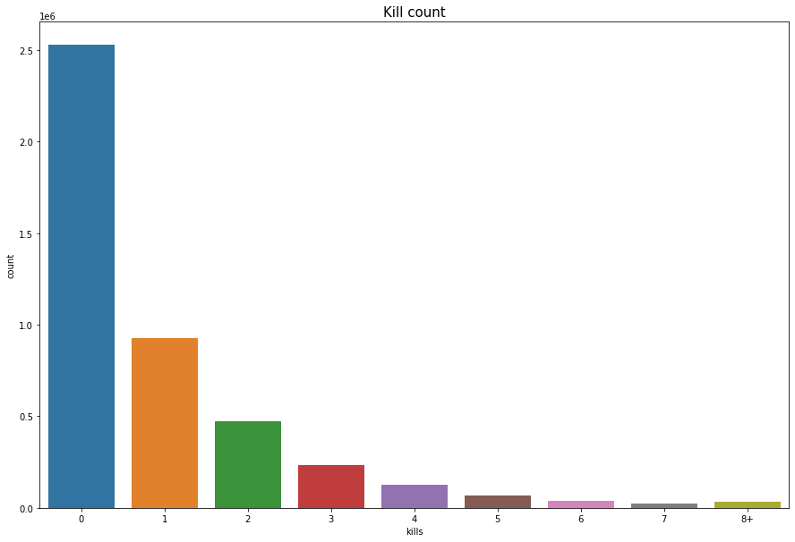

```python
data=train.copy()
data.loc[data['kills']>data['kills'].quantile(0.99)]='8+'
plt.figure(figsize=(15,10))
sns.countplot(data['kills'].astype('str').sort_values())
plt.title("Kill count",fontsize=15)
plt.show()
```

#### 统计没有击杀的玩家是否至少造成了伤害。

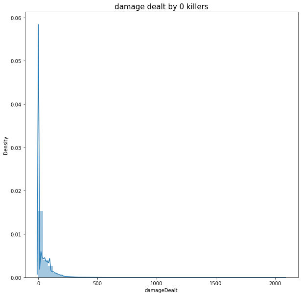

```python
data=train.copy()
data=data[data['kills']==0]
plt.figure(figsize=(10,10))
plt.title("damage dealt by 0 killers",fontsize=15)
sns.distplot(data['damageDealt'])
plt.show()
```

可以发现大部分都没有造成伤害

#### 统计有多少玩家没有击杀但是赢得了胜利。

```python
print("{} players have won without a single kill!". format(len(data[data['winPlacePerc']==1])))
data[data['winPlacePerc']==1].head()
```

```
16666 players have won without a single kill!
```

|  | Id | groupId | matchId | assists | boosts | damageDealt | DBNOs | headshotKills | heals | killPlace | ... | normal-duo | normal-duo-fpp | normal-solo | normal-solo-fpp | normal-squad | normal-squad-fpp | solo | solo-fpp | squad | squad-fpp |
| --- | --- | --- | --- | --- | --- | --- | --- | --- | --- | --- | --- | --- | --- | --- | --- | --- | --- | --- | --- | --- | --- |
| 107 | 7970b4ea89e81e | abf9e2780b9f48 | 04832cfd74ff30 | 1 | 1 | 58.360 | 0 | 0 | 2 | 38 | ... | 0 | 0 | 0 | 0 | 0 | 0 | 0 | 0 | 1 | 0 |
| 118 | 953577684b828a | 54ce33c41ef9ff | c5d412db6dbee4 | 2 | 6 | 76.110 | 0 | 0 | 12 | 45 | ... | 0 | 0 | 0 | 0 | 0 | 0 | 0 | 0 | 0 | 0 |
| 493 | 575f5ad18b60ac | 9ed86c84df9fe7 | 728a56582842f8 | 1 | 3 | 275.900 | 0 | 0 | 2 | 44 | ... | 0 | 0 | 0 | 0 | 0 | 0 | 0 | 0 | 0 | 1 |
| 1225 | c1bda1f071fbc4 | 55fe3f03feaa0e | f8927d87063fd3 | 1 | 3 | 3.669 | 0 | 0 | 3 | 36 | ... | 0 | 0 | 0 | 0 | 0 | 0 | 0 | 0 | 0 | 1 |
| 1289 | e825b1eab36bcc | 6ad3351953b514 | 44fa051734f50f | 2 | 2 | 126.800 | 0 | 0 | 1 | 44 | ... | 0 | 0 | 0 | 0 | 0 | 0 | 0 | 0 | 0 | 0 |

5 rows × 48 columns

可以发现有16666名玩家没有击杀但是赢得了胜利，而比赛类型大多为多排。

#### 统计有多少玩家没有击造成伤害但是赢得了胜利。

```python
data1=train[train['damageDealt']==0].copy()
print("{} players have won without dealing damage!".format (len(data1[data1['winPlacePerc']==1])))
data1[data1['winPlacePerc']==1].head()
```

```
4770 players have won without dealing damage!
```

|  | Id | groupId | matchId | assists | boosts | damageDealt | DBNOs | headshotKills | heals | killPlace | ... | normal-duo | normal-duo-fpp | normal-solo | normal-solo-fpp | normal-squad | normal-squad-fpp | solo | solo-fpp | squad | squad-fpp |
| --- | --- | --- | --- | --- | --- | --- | --- | --- | --- | --- | --- | --- | --- | --- | --- | --- | --- | --- | --- | --- | --- |
| 2931 | 2aed71cfd36e7f | c6e699a280f2a6 | bbbed73da58547 | 0 | 2 | 0.0 | 0 | 0 | 0 | 46 | ... | 0 | 0 | 0 | 0 | 0 | 0 | 0 | 0 | 1 | 0 |
| 3114 | f485c54e3c9652 | 43b9495099889d | 1f78e2436506db | 0 | 0 | 0.0 | 0 | 0 | 0 | 38 | ... | 0 | 0 | 0 | 0 | 0 | 0 | 0 | 0 | 0 | 1 |
| 3571 | 871a7cf56b5e1a | 744c69678bd2ba | 2e3b45023dcb07 | 0 | 4 | 0.0 | 0 | 0 | 5 | 40 | ... | 0 | 0 | 0 | 0 | 0 | 0 | 0 | 0 | 0 | 1 |
| 3702 | 3fc123559fc935 | 5cef1df7ee3551 | 01aead02bb8901 | 0 | 0 | 0.0 | 0 | 0 | 0 | 1 | ... | 0 | 0 | 0 | 0 | 0 | 0 | 1 | 0 | 0 | 0 |
| 5288 | 0017d4c0ec3125 | a97f0da93e4768 | f6d508a32b64c4 | 0 | 2 | 0.0 | 0 | 0 | 10 | 44 | ... | 0 | 0 | 0 | 0 | 0 | 0 | 0 | 0 | 0 | 1 |

5 rows × 48 columns

可以发现有4770名玩家没有造成伤害但是赢得了胜利

#### 可视化击杀数和百分比排名之间的关系。

##### 散点图

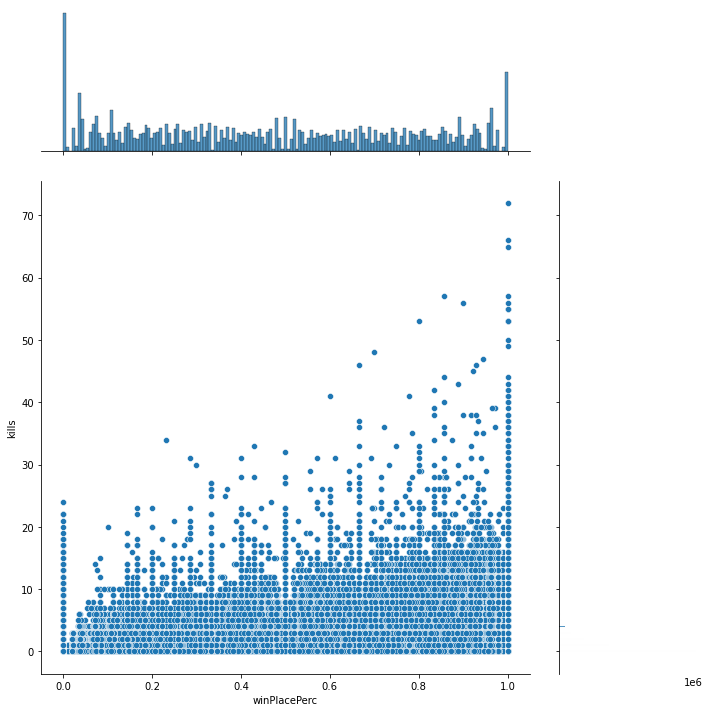

```python
sns.jointplot(x="winPlacePerc",y="kills",data=train,height=10,ratio=3)
plt.show()
```

##### 箱线图

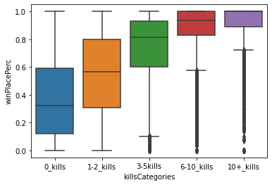

```python
kills=train.copy()
kills['killsCategories']=pd.cut(kills['kills'],
                                [-1,0,2,5,10,60],
                                labels=['0_kills','1-2_kills','3-5kills','6-10_kills','10+_kills'])
sns.boxplot(x="killsCategories", y="winPlacePerc",data=kills)
plt.show()
```

可以发现击杀数和百分比排名之间呈现较为明显的正相关性。

### 探索性分析—步行数据

#### 统计99%玩家的步行距离。

```python
print("99% of people have walked {}m or less.". format(train['walkDistance'].quantile(0.99)))
```

```
99% of people have walked 4396.0m or less.
```

#### 可视化步行数据。

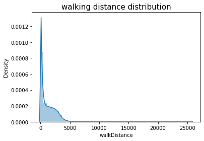

```python
data=train.copy()
plt.title("walking distance distribution",fontsize=15)
sns.distplot(data['walkDistance'])
plt.show()
```

#### 统计有多少玩家死亡前没有任何移动。

```python
print("{} players walked 0 meters.".format(len(data[data['walkDistance']==0])))
print("this means that they die before even taking a step.")
```

```
98067 players walked 0 meters.
this means that they die before even taking a step.
```

可以发现有98067名玩家死亡前没有任何移动。

#### 可视化步行距离和百分比排名之间的关系。

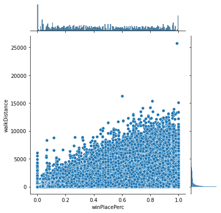

```python
sns.jointplot(x="winPlacePerc",y="walkDistance",data=train)
plt.show()
```

可以发现步行数据与百分比排名也具有较强的相关性。

### 探索性分析—载具数据

#### 统计99%玩家的载具距离。

```python
print("99% of people have drived {}m. or less.".format(train['rideDistance'].quantile(0.99)))
```

```
99% of people have drived 6966.0m. or less.
```

可以发现99%的玩家搭乘载具行进的距离少于等于6966米。

#### 可视化载具移动距离

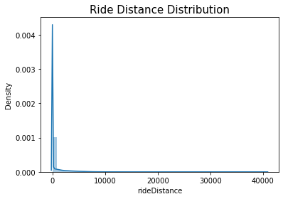

```python
data=train.copy()
plt.title("Ride Distance Distribution",fontsize=15)
sns.distplot(data['rideDistance'])
plt.show()
```

#### 可视化破坏载具数量和百分比排名之间的关系。

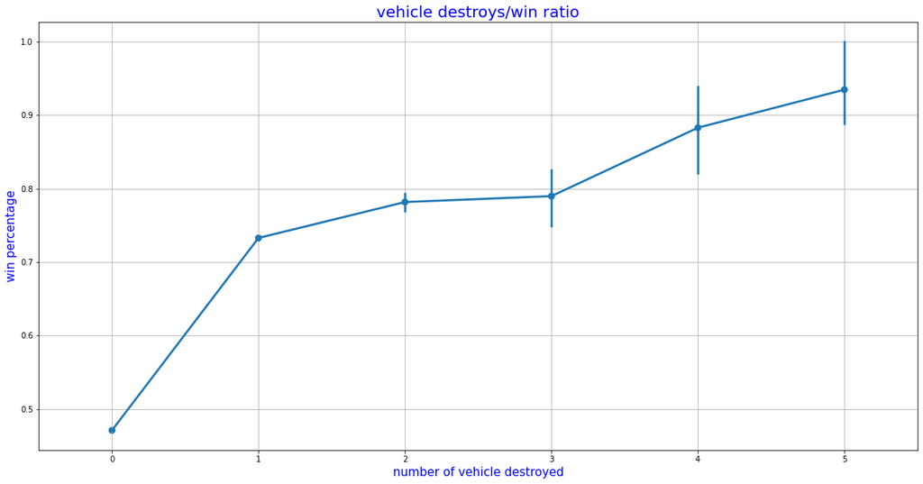

```python
f,ax1=plt.subplots(figsize=(20,10))
sns.pointplot(x='vehicleDestroys',y='winPlacePerc',data=data)
plt.xlabel('number of vehicle destroyed',fontsize=15,color='blue')
plt.ylabel('win percentage',fontsize=15,color='blue')
plt.title('vehicle destroys/win ratio',fontsize=20,color='blue')
plt.grid()
plt.show()
```

### 探索性分析—游泳数据

#### 统计99%玩家的游泳距离。

```python
print("99% of people have swimmed {}m or less.".format(train['swimDistance'].quantile(0.99)))
```

```
99% of people have swimmed 123.0m or less.
```

可以发现99%的玩家的游泳距离少于等于123米。

#### 可视化游泳数据

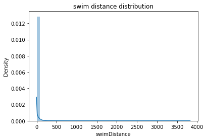

```python
data=train.copy()
plt.figure
plt.title("swim distance distribution")
sns.distplot(data['swimDistance'])
plt.show()
```

#### 可视化游泳距离与百分比排名之间的关系。

##### 箱线图

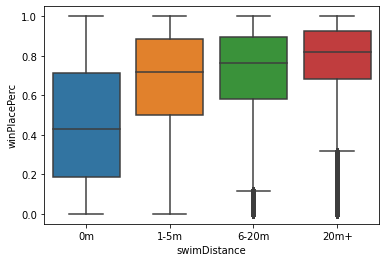

```python
swim=train.copy()
swim['swimDistance']=pd.cut(swim['swimDistance'],
                             [-1,0,5,20,5286],
                             labels=['0m','1-5m','6-20m','20m+'])
plt.figure
sns.boxplot(x="swimDistance",y="winPlacePerc",data=swim)
plt.show()
```

由于PUBG存在沙漠地图，我们甚至可以推断出本场比赛的具体地图。并且游泳距离和百分比排名也有轻微的正相关性。

### 探索性分析—治疗和能量数据

#### 统计99%玩家的治疗和能量道具数据。

##### 治疗道具数量

```python
print("99% of people use {} or less heals.".format(train['heals'].quantile(0.99)))
```

```
99% of people use 12.0 or less heals.
```

##### 能量道具数量（Boosting）

```python
print("99% of people use {} or less boosts.".format(train['boosts'].quantile(0.99)))
```

```
99% of people use 7.0 or less boosts.
```

可以发现99%的玩家使用治疗道具的数量少于等于12，使用能量道具的数量少于等于7。

#### 可视化使用治疗和能量道具数量和百分比排名之间的关系。

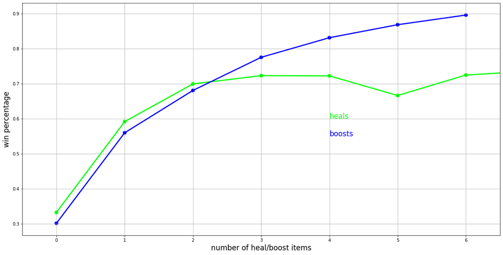

```python
data = train.copy()
data=data[data['heals']<data['heals'].quantile(0.99)]
data=data[data['boosts']<data['boosts'].quantile(0.99)]
f,ax1=plt.subplots(figsize=(20,10))
sns.pointplot(x='heals',y='winPlacePerc',data=data,color='lime',alpha=0.8)
sns.pointplot(x='boosts',y='winPlacePerc',data=data,color='blue',alpha=0.8)
plt.text(4,0.6,'heals',color='lime',fontsize=17)
plt.text(4,0.55,'boosts',color='blue',fontsize=17)
plt.xlabel('number of heal/boost items',fontsize=17)
plt.ylabel('win percentage',fontsize=17)
plt.grid()
plt.show()
```

可以发现治疗和能量道具的使用都与百分比排名具有正相关的关系，能量道具的使用与百分比排名的正相关关系更加明显。

### 探索性分析—参赛数据

#### 统计每场比赛参赛人数的场次。

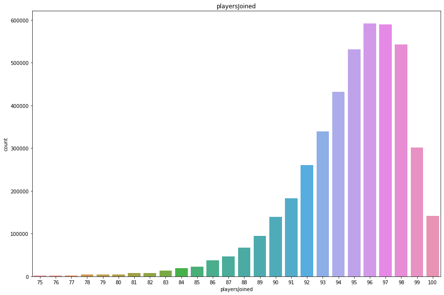

```python
train['playersJoined'] = train.groupby('matchId')['matchId'].transform('count')
plt.figure(figsize=(15,10))
sns.countplot(train[train['playersJoined']>=75]['playersJoined'])
plt.title('playersJoined')
plt.show()
```

有一些少于75名玩家的比赛没有显示在这里。可以发现大多数比赛几乎都是爆满的，有近100名玩家。

### 探索性分析—爆头击杀数据

#### 首先查看整个数据集并创建一个新特性'headshot_rate'。

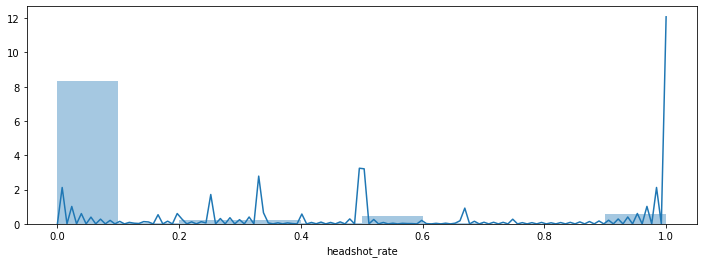

```python
train['headshot_rate'] = train['headshotKills'] / train['kills']
train['headshot_rate'] = train['headshot_rate'].fillna(0)
plt.figure(figsize=(12,4))
sns.distplot(train['headshot_rate'], bins=10)
plt.show()
```

可以发现大多数玩家在0到10%的区域得分。然而有一些异常数据显示有超过9杀拥有100%的爆头率。

#### 统计击杀距离的分布。

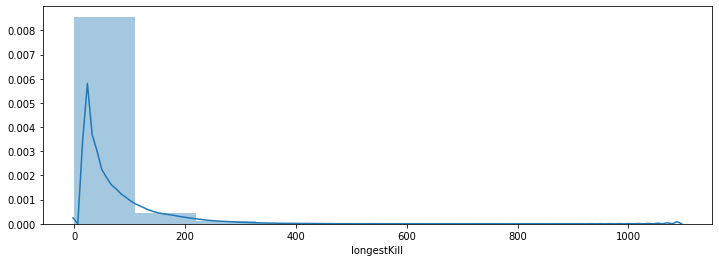

```python
plt.figure(figsize=(12,4))
sns.distplot(train['longestKill'], bins=10)
plt.show()
```

可以发现大多数击杀都是在100米或更近的距离内完成的。也有一些例外，玩家能在1公里以上的地方击杀对手

### 探索性分析—武器数据

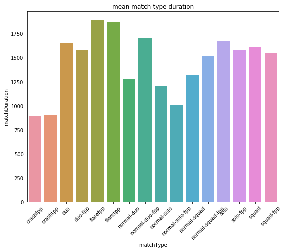

```python
plt.figure(figsize=(9,7))
match_dur=train.groupby('matchType')['matchDuration'].agg('mean')
sns.barplot(x=match_dur.index,y=match_dur)
plt.gca().set_xticklabels(match_dur.index,rotation='45')
plt.gca().set_title('mean match-type duration')
plt.show()
```

#### 统计玩家武器数量与获胜几率的关系。

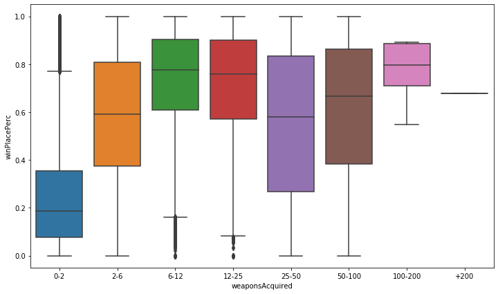

```python
weapons_num=pd.cut(train['weaponsAcquired'],[0,2,6,12,25,50,100,200,300],
                   labels=['0-2','2-6','6-12','12-25','25-50','50-100','100-200','+200'])
plt.figure(figsize=(12,7))
sns.boxplot(x=weapons_num,y='winPlacePerc',data=train)
plt.show()
```

首先将获得的武器数量分类，以便正确地观察。可以发现拥有6-25件的武器会让玩家的获胜几率更大。这个数字比较合理，因为超过100就有可能是作弊。

#### 统计击杀数量和对敌人造成的总伤害之间的关系。

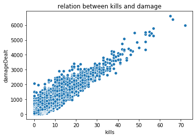

```python
sns.scatterplot(train.kills,train.damageDealt)
plt.title('relation between kills and damage')
plt.show()
```

可以发现这两个属性呈现正相关的关系。

#### 统计九个属性与比赛百分比排名的关系

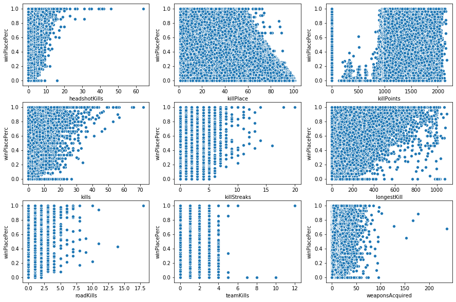

```python
kills = train[['headshotKills','killPlace','killPoints','kills','killStreaks','longestKill','roadKills','teamKills'
               ,'weaponsAcquired','winPlacePerc']]
kills_features = ['headshotKills','killPlace','killPoints','kills','killStreaks','longestKill','roadKills'
                  ,'teamKills','weaponsAcquired']
def scatter (feature_name):
        sns.scatterplot(x=feature_name,y='winPlacePerc',data=kills)

plt.figure(figsize=(15,10))
plt.subplot(3,3,1)
scatter(kills_features[0])
plt.subplot(3,3,2)
scatter(kills_features[1])
plt.subplot(3,3,3)
scatter(kills_features[2])
plt.subplot(3,3,4)
scatter(kills_features[3])
plt.subplot(3,3,5)
scatter(kills_features[4])
plt.subplot(3,3,6)
scatter(kills_features[5])
plt.subplot(3,3,7)
scatter(kills_features[6])
plt.subplot(3,3,8)
scatter(kills_features[7])
plt.subplot(3,3,9)
scatter(kills_features[8])
plt.show()
```

## 标称属性分析

### 组队类型分析

#### 数据中单排 双排 四排所占比例

```python
datamt = train.copy()
mapper = lambda x: 'solo' if ('solo' in x) else 'duo' if ('duo' in x) or ('crash' in x) else 'squad'
datamt['matchTypeSimple'] = datamt['matchType'].apply(mapper)
datamt.head()
```

|  | Id | groupId | matchId | assists | boosts | damageDealt | DBNOs | headshotKills | heals | killPlace | ... | normal-duo-fpp | normal-solo | normal-solo-fpp | normal-squad | normal-squad-fpp | solo | solo-fpp | squad | squad-fpp | matchTypeSimple |
| --- | --- | --- | --- | --- | --- | --- | --- | --- | --- | --- | --- | --- | --- | --- | --- | --- | --- | --- | --- | --- | --- |
| 0 | 7f96b2f878858a | 4d4b580de459be | a10357fd1a4a91 | 0 | 0 | 0.00 | 0 | 0 | 0 | 60 | ... | 0 | 0 | 0 | 0 | 0 | 0 | 0 | 0 | 1 | squad |
| 1 | eef90569b9d03c | 684d5656442f9e | aeb375fc57110c | 0 | 0 | 91.47 | 0 | 0 | 0 | 57 | ... | 0 | 0 | 0 | 0 | 0 | 0 | 0 | 0 | 1 | squad |
| 2 | 1eaf90ac73de72 | 6a4a42c3245a74 | 110163d8bb94ae | 1 | 0 | 68.00 | 0 | 0 | 0 | 47 | ... | 0 | 0 | 0 | 0 | 0 | 0 | 0 | 0 | 0 | duo |
| 3 | 4616d365dd2853 | a930a9c79cd721 | f1f1f4ef412d7e | 0 | 0 | 32.90 | 0 | 0 | 0 | 75 | ... | 0 | 0 | 0 | 0 | 0 | 0 | 0 | 0 | 1 | squad |
| 4 | 315c96c26c9aac | de04010b3458dd | 6dc8ff871e21e6 | 0 | 0 | 100.00 | 0 | 0 | 0 | 45 | ... | 0 | 0 | 0 | 0 | 0 | 0 | 1 | 0 | 0 | solo |

5 rows × 49 columns

```python
s=datamt[datamt['matchTypeSimple'] == 'solo']
d=datamt[datamt['matchTypeSimple'] == 'duo']
sq=datamt[datamt['matchTypeSimple'] == 'squad']
```

```python
print("there are {} ({}%) solo games.".format(len(s),100*len(s)/len(train)))
print("there are {} ({}%) duo games.".format(len(d),100*len(d)/len(train)))
print("there are {} ({}%) squad gmaes.". format(len(sq),100*len(sq)/len(train)))
```

```
there are 720316 (16.203604350198834%) solo games.
there are 1322516 (29.750173549952468%) duo games.
there are 2402574 (54.0462220998487%) squad gmaes.
```

#### 可视化单排、双排、四排的击杀数与排名的关系

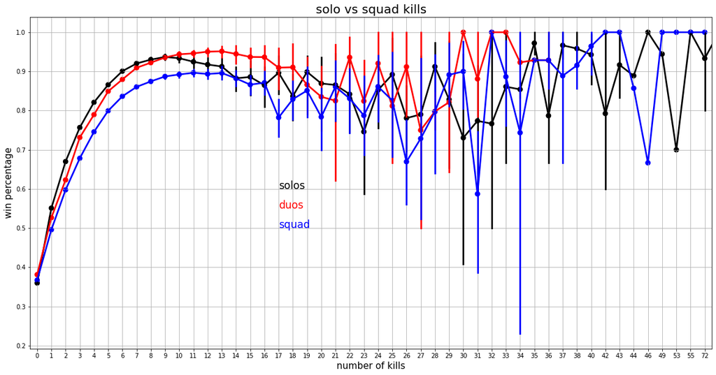

```python
f,ax1=plt.subplots(figsize=(20,10))
sns.pointplot('kills',y='winPlacePerc',data=s, color='black',alpha=0.8)
sns.pointplot(x='kills',y='winPlacePerc',data=d,color='red',alpha=0.8)
sns.pointplot(x='kills',y='winPlacePerc',data=sq,color='blue',alpha=0.8)
plt.text(17,0.6,'solos',color='black',fontsize=17)
plt.text(17,0.55,'duos',color='red',fontsize=17)
plt.text(17,0.5,'squad',color='blue',fontsize=17)
plt.xlabel('number of kills',fontsize=15)
plt.ylabel('win percentage',fontsize=15)
plt.title('solo vs squad kills', fontsize=20)
plt.grid()
plt.show()
```

#### 可视化单双排、四排的击倒数、助攻数、复活数与排名的关系

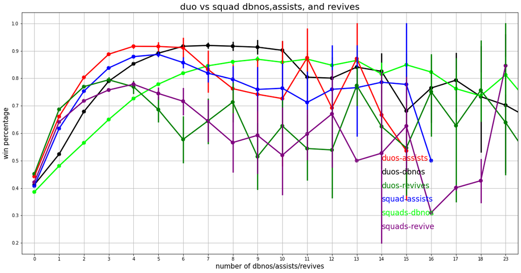

```python
f,ax1=plt.subplots(figsize=(20,10))
sns.pointplot(x='DBNOs', y='winPlacePerc',data=d,color='black',alpha=0.8)
sns.pointplot(x='DBNOs', y='winPlacePerc',data=sq,color='lime',alpha=0.8)
sns.pointplot(x='assists', y='winPlacePerc',data=d,color='red',alpha=0.8)
sns.pointplot(x='assists', y='winPlacePerc',data=sq,color='blue',alpha=0.8)
sns.pointplot(x='revives', y='winPlacePerc',data=d,color='green',alpha=0.8)
sns.pointplot(x='revives', y='winPlacePerc',data=sq,color='purple',alpha=0.8)
plt.text(14,0.5,'duos-assists',color='red',fontsize=17)
plt.text(14,0.45,'duos-dbnos',color='black',fontsize=17)
plt.text(14,0.4,'duos-revives',color='green',fontsize=17)
plt.text(14,0.35,'squad-assists',color='blue',fontsize=17)
plt.text(14,0.3,'squads-dbnos',color='lime',fontsize=17)
plt.text(14,0.25,'squads-revive',color='purple',fontsize=17)
plt.xlabel('number of dbnos/assists/revives',fontsize=15)
plt.ylabel('win percentage',fontsize=15)
plt.title('duo vs squad dbnos,assists, and revives',fontsize=20)
plt.grid()
plt.show()
```

可以发现，在多人匹配模式下，更多的助攻和击倒数更有可能获得更高的名次，然而更多的复活数量并非如此，更多的复活甚至会导致更低的名次。

## 属性关联性分析

### 可视化变量间的皮尔森相关性矩阵

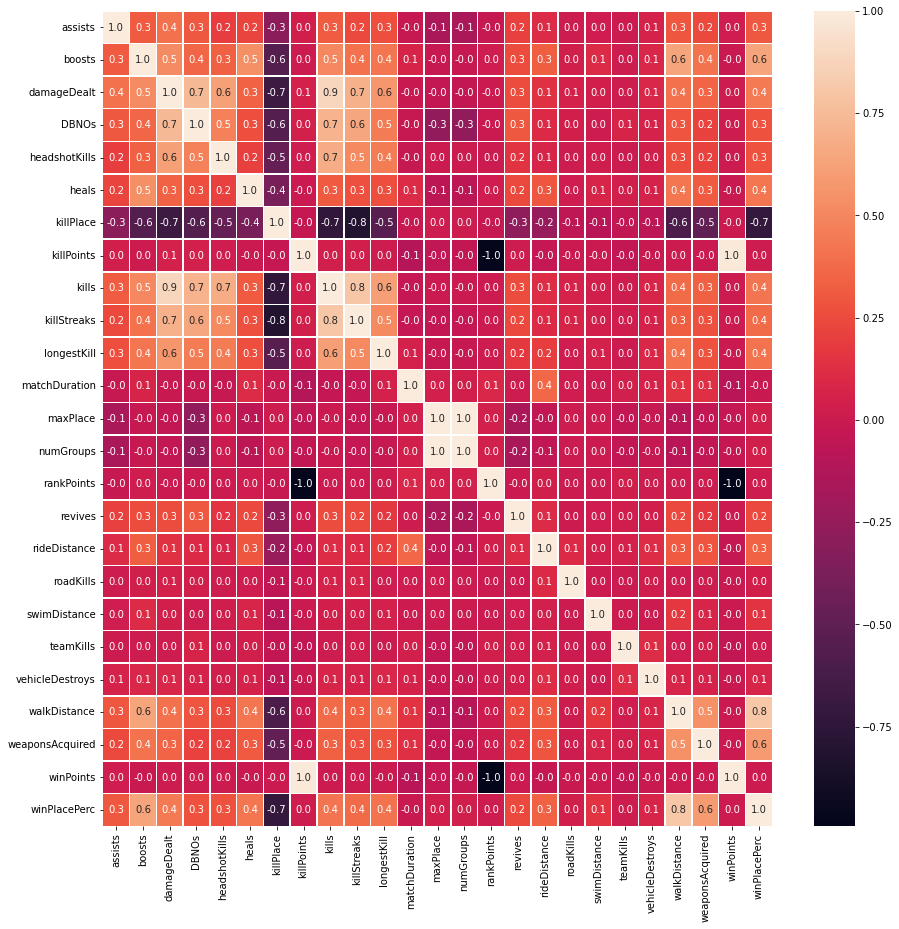

```python
f,ax=plt.subplots(figsize=(15,15))
sns.heatmap(train.iloc[:, :29].corr(),annot=True,linewidths=.5,fmt='.1f',ax=ax)
plt.show()
```

这里我们发现击杀排名与百分比排名呈现负相关关系，因为击杀排名是递增的，而百分比排名是递减的。

### 进一步可视化与百分比排名相关度最高的前5个属性

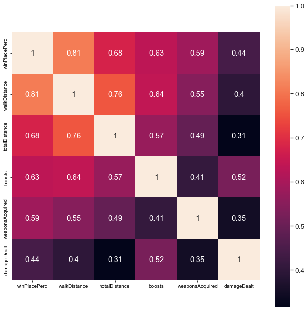

```python
k=6
f,ax=plt.subplots(figsize=(11,11))
cols=train.corr().nlargest(k,'winPlacePerc')['winPlacePerc'].index
sns.set(font_scale=1.25)
hm=sns.heatmap(train[cols].corr(),cbar=True,annot=True,square=True)
plt.show()
```

观察关联矩阵我们可以发现步行距离、总距离、能量道具使用数量、获取武器数量、造成的总伤害这五个属性与百分比排名间具有最强的正相关关系

### 绘制这些变量之间的散点图 可视化两两关系

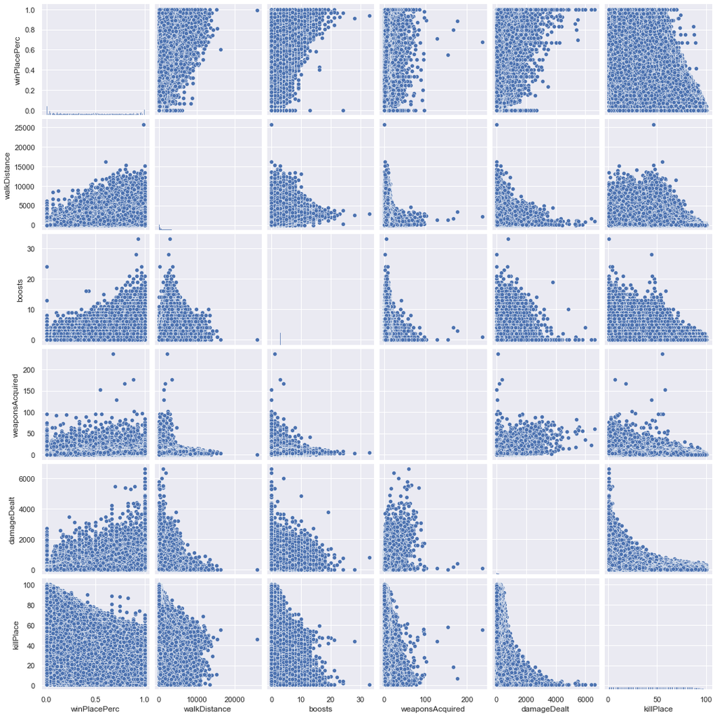

```python
sns.set()
cols=['winPlacePerc','walkDistance','boosts','weaponsAcquired','damageDealt','killPlace']
sns.pairplot(train[cols],size=2.5)
plt.show()
```